# Prognostic analysis

2025-02-28

# 1 Background

We identified the over-expressed mCRPC proteins from the discovery dataset. As we have the OS clinical data, we can perform prognostic analysis to identify if the overexpressed proteins is associated with survival.

# 2 Objectives

1. Clinical features
2. Protein - Uni-variate
- Continuous expression
- Binarize the protein to high vs low
3. Protein - Multi-variate
4. Heatmap Viz

# 3 Conclusion

We will use the binarized NPX protein value when correlating protein expression with OS. In addition, account for PSA, LDH and ALk Phos during the multivariate analysis. For serial samples, we wrote a function to select the patient with the highest NPX value for a given protein.

# 4 Pre-processing

## 4.1 Loading packages

```r
library(here)
library(tidyverse)
library(readxl)
library(readr)
library(stringr)
library(ggplot2)
library(paletteer)
library(VennDiagram)
library(ggvenn)
# Survival
library(survival)
library(ggsurvfit)
library(survminer)
# Heatmap
library(ComplexHeatmap)
library(circlize)
```

## 4.2 Directories

```r
wd <- list()
wd$main <- here()
wd$data <- file.path(wd$main, "data")
wd$manishData <- file.path(wd$data, "raw/data_fromManish")
wd$d2024 <- file.path(wd$data, "updated_2024")
wd$d2024_npx <- file.path(wd$d2024, "NPX_data")
wd$output <- file.path(wd$main, "output")
wd$script <- file.path(wd$main, "scripts")

wd$outData <- file.path(wd$output, "data")
wd$outCurr <- file.path(wd$output, "04_Prognosis")
```

Create directories

```r
if (!file.exists(wd$outCurr)) {
  dir.create(wd$outCurr)
} else {
  print("Directory already exists")
}
```

```
## [1] "Directory already exists"
```

Load functions

```r
source(file.path(wd$script, "functions.R"))
```

## 4.3 Load data

Load the processed file

```r
load(file.path(wd$outData, "01_Metadata.Rdata"))
load(file.path(wd$outData, "02_data.Rdata"))
```

# 5 Obj 1: Clinical features

Identify the proteins defining group CD

```r
length(cd_prot)
```

```
## [1] 456
```

Gather the metadata

Select only the psomagen (discovery cohort)

```r
# Lets get the metadata - This contains the sample ID
df_meta_f_psom <- df_meta_f %>%
  filter(Psomagen == "Y") %>%
  filter(cohort == "C_D")

meta_psom_f <- df_meta_f_psom %>%
  left_join(meta_psom)
# Fix metadata
# Fix the PSA to numeric
meta_psom_f <- meta_psom_f %>%
  mutate(psa = gsub("<", "", psa),
         psa = as.numeric(psa),
         ldh = as.numeric(ldh),
         alk_ph = as.numeric(alk_ph))
```

## 5.1 Clinical factors

Run cox on the clinical variables

**Use a Cox Model with Clustered Standard Errors**

```r
df_cox <- meta_psom_f %>%
  filter(! duplicated(mrn))

# Fit one protein using the clustered standard error (if we are using the data frame with mulitple patients.)
model_psa <- coxph(Surv(OS, death) ~ psa, data = meta_psom_f, cluster = mrn)
model_ldh <- coxph(Surv(OS, death) ~ ldh, data = meta_psom_f, , cluster = mrn)
model_alk <- coxph(Surv(OS, death) ~ alk_ph, data = meta_psom_f, cluster = mrn)

# Fit clinical factor (not accounting for patients)
# Since the PSA is the same in each patient use this is more appropriate
model_psa2 <- coxph(Surv(OS, death) ~ psa , data = df_cox)
model_ldh2 <- coxph(Surv(OS, death) ~ ldh, data = df_cox)
model_alk2 <- coxph(Surv(OS, death) ~ alk_ph, data = df_cox)
```

Extract results of all

```r
clin_var <- c("psa", "ldh", "alk_ph")
results <- cox_extract(clin_var, df_cox)

final_results <- do.call(rbind, results) %>%
  mutate(Group = "Discovery")

final_results_dis <- final_results
```

# 6 Obj 2: Uni-variate Protein

For the proteins highly expressed in C_D, we run a cox proportional analysis. Since we have serial patients, these patients have the same OS. So it would be incorrect to use repeated OS measurement for prognosis. An idea that for each protein, take the patient that has the highest expression of that protein (then discard the remaining serial samples). Next we can run the cox regression. This will means that duplicated patietn are not included.

We think this is not the case in the discovery cohort, ie - in the discovery cohort only 1 mCRPC patietns were profiled.

```r
# Function to select the highest expression per patient
select_highest_expression
```

```
## function (df)
## {
##     df %>% group_by(mrn) %>% slice_max(order_by = NPX, n = 1,
##         with_ties = FALSE) %>% ungroup()
## }
```

Lets show an example for one protein

```r
# Extract the NPX value of a gene defining C & D group
eg_protein <- cd_prot[2]

# Select highest NPX per patietn
npx_exp <- dat_NPX %>% dplyr::filter(OlinkID %in% eg_protein) %>%
  dplyr::rename(sample_id = SampleID) %>%
  select(sample_id, NPX) %>%
  mutate(sample_id = as.character(sample_id))

# Combine with metadata
tmp_df <- meta_psom_f %>% left_join(npx_exp)
# Apply function to select the highest NPX per patient
filtered_data <- select_highest_expression(tmp_df)
```

We can indicate a column to binarise the NPX value.

```r
filtered_data <- filtered_data %>%
  mutate(
    npx_median = median(NPX),
    npx_bin = case_when(NPX >= npx_median ~ "high",
                        NPX < npx_median ~ "low"),
    npx_bin = factor(npx_bin, levels = c("low", "high")))

# Fit cox with continuous data
model1 <- coxph(Surv(OS, death) ~ NPX, data = filtered_data)

# Fit cox with binarized data
model2 <- coxph(Surv(OS, death) ~ npx_bin, data = filtered_data)
```

Extract the cox value

```r
# Function to extract summary from Cox model results
extract_cox_summary <- function(model, OlinkID) {
  # Extract coefficients and confidence intervals
  coef_summary <- summary(model)$coefficients
  coef_summary2 <- summary(model)$conf.int

  coef_names <- row.names(coef_summary)
  coef <- coef_summary[, 1]
  lower_bound <- coef_summary2[, 3]
  upper_bound <- coef_summary2[, 4]
  p_value <- coef_summary[, 5]
  exp_coef <- coef_summary2[, 1]  # HR (Hazard Ratio)

  # Create the summary data frame
  summary_df <- data.frame(
    OlinkID = OlinkID,
    Coefficient = coef,
    Lower_Bound = lower_bound,
    Upper_Bound = upper_bound,
    P_Value = p_value,
    HR = exp_coef,
    row.names = coef_names
  )

  return(summary_df)
}
```

Examine the results

```r
cox_results <- extract_cox_summary(model1, eg_protein)
cox_results2 <- extract_cox_summary(model2, eg_protein)
```

Lets run in all proteins, selecting the highest patient per- protein expression

```r
tmp_npx <- dat1_final
results <- analyze_proteins_highest(cd_prot, npx_in=tmp_npx, meta_in=meta_psom_f)
results <- left_join(results, df_id_pro)
res_dis_uni <- results
```

## 6.1 Compare binned vs continous

Check KLK3 and YAP1

```r
res_dis_uni %>% filter(Assay %in% c("KLK3", "YAP1")) %>%
  select(Assay, OlinkID, P_Value, HR, bin_P_Value, bin_HR)
```

```
##   Assay  OlinkID      P_Value       HR bin_P_Value   bin_HR
## 1  YAP1 OID31113 0.0008181531 2.482492 0.016723485 2.300150
## 2  KLK3 OID30364 0.0001212291 1.222288 0.003556965 2.717312
```

Number of proteins considered significant in continous NPX

```r
sig1 <- res_dis_uni %>% filter(P_Value <0.05)
nrow(sig1)
```

```
## [1] 336
```

```r
sig2 <- res_dis_uni %>% filter(bin_P_Value <0.05)
nrow(sig2)
```

```
## [1] 268
```

Show overlap

```r
un_a <- sig1$OlinkID
un_b <- sig2$OlinkID

overlap <- calculate.overlap(
x <- list("Cont"=un_a,
          "Binary"=un_b))

ggvenn(
  x,
  fill_color = pal.cond3,
  show_percentage = FALSE,
  stroke_size = 0.5, set_name_size = 4
)
```

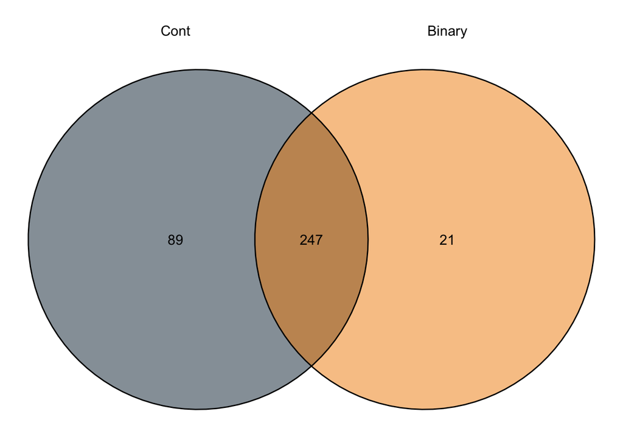

> Lets stick to using the binarized NPX for now. Because it will aid risk stratification

## 6.2 Clusterd model

> WE did not use this model

Since we have serial patients, these patients have the same OS. So it would be incorrect to use repeated measurement. One alternative is to use a cox model that accounts for repeated measurement, called “clustered standard error”.

**Use a Cox Model with Clustered Standard Errors**

```r
# Extract the NPX value of a gene defining C & D group
eg_protein <- cd_prot[2]
# Binarize protein to low or high based on median
npx_exp <- dat_NPX %>% dplyr::filter(OlinkID %in% eg_protein) %>%
  rename(sample_id = SampleID) %>%
  select(sample_id, NPX) %>%
  mutate(sample_id = as.character(sample_id),
         npx_median = median(NPX),
         npx_bin = case_when(NPX >= npx_median ~ "high",
                             NPX < npx_median ~ "low"),
         npx_bin = factor(npx_bin, levels = c("low", "high")))
# Combine with metadata
tmp_df <- meta_psom_f %>% left_join(npx_exp)

# Fit one protein using the clustered standard error
model <- coxph(Surv(OS, death) ~ NPX, data = tmp_df, cluster = mrn)
model2 <- coxph(Surv(OS, death) ~ npx_bin, data = tmp_df, cluster = mrn)

# Fit one protein using basic function
model3 <- coxph(Surv(OS, death) ~ npx_bin, data = tmp_df)
```

To simplify analysis on all proteins, we wrote a function (using the cluster parameter).

```r
cox_p_val <- 0.05
tmp_npx <- dat_NPX
# analyze_proteins_cluster is the function
results <- analyze_proteins_cluster(cd_prot, npx_in=tmp_npx, meta_in=meta_psom_f)

final_results <- do.call(rbind, results) %>%
  mutate(Group = "Discovery") %>%
  # Adjust the P_value
  mutate(adj_p_values = p.adjust(P_Value, method = "BH"))


final_results_dis_uni <- final_results

# Join with Olink identifier
final_results_dis_uni <- final_results_dis_uni %>% left_join(df_id_pro) %>%
  mutate(
    Lower_Bound = round(Lower_Bound, 2),
    Upper_Bound = round(Upper_Bound, 2),
    HR = round(HR, 2),
    Sig = case_when(
      adj_p_values <= cox_p_val & Lower_Bound >=1 ~ "Sig",
      adj_p_values <= cox_p_val & Lower_Bound <=1 & Upper_Bound <=1 ~ "Sig",
      TRUE ~ "Non") )
write.csv(final_results_dis_uni, file.path(wd$outCurr, "HR_values_mCRPC_specific_univariate.csv"))
```

# 7 Obj 3: Multi-variate Protein

We use only the proteins considered significant at the uni-variate level

```r
uni_sig <- res_dis_uni %>% filter(P_Value < 0.05) %>% pull(OlinkID)
# We run all protein for now - we can filter later
uni_sig <- res_dis_uni$OlinkID
```

To simplify analysis on all proteins, we wrote a function.

```r
# Run function on multivariate analysis
results <- analyze_proteins_multi(uni_sig, npx_in=tmp_npx, meta_in=meta_psom_f)
results <- left_join(results, df_id_pro)
res_dis_mult <- results
```

Show overlap

```r
sig1 <- res_dis_mult %>% filter(P_Value <0.05)
sig2 <- res_dis_mult %>% filter(bin_P_Value <0.05)

un_a <- sig1$OlinkID
un_b <- sig2$OlinkID

overlap <- calculate.overlap(
x <- list("Cont"=un_a,
          "Binary"=un_b))
ggvenn(
  x,
  fill_color = pal.cond3,
  show_percentage = FALSE,
  stroke_size = 0.5, set_name_size = 4
)
```

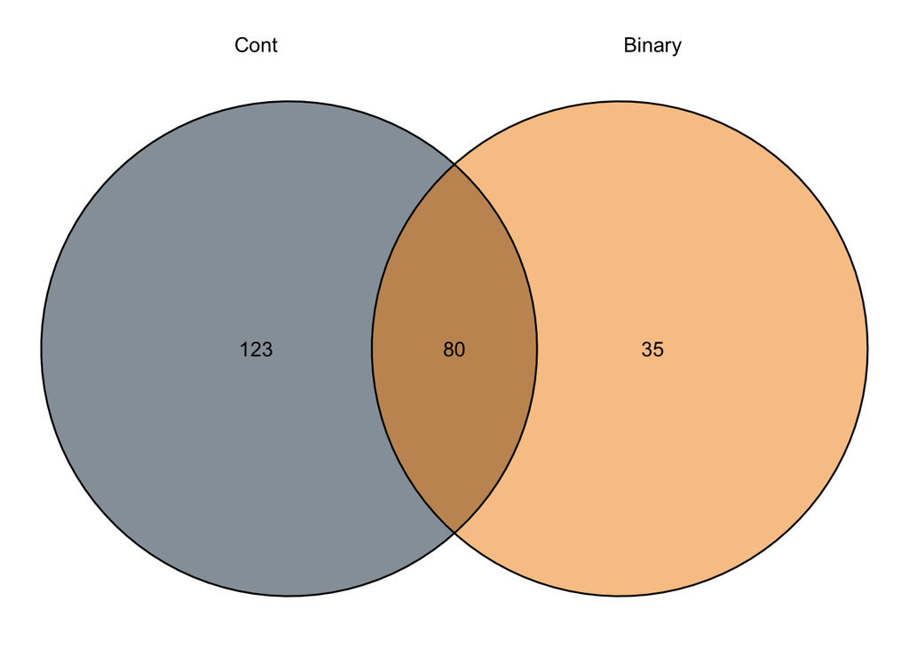

Check KLK3 and YAP1

```r
res_dis_mult %>% filter(Assay %in% c("KLK3", "YAP1")) %>%
  select(Assay, OlinkID, P_Value, HR, bin_P_Value, bin_HR)
```

```
##   Assay  OlinkID    P_Value       HR bin_P_Value   bin_HR
## 1  YAP1 OID31113 0.08608869 1.733851 0.029560148 2.246456
## 2  KLK3 OID30364 0.00524820 1.200738 0.003049062 3.073471
```

## 7.1 Clean up

Format and save the results

```r
cox_p_val <- 0.05
res_dis_mult <- res_dis_mult %>%
  mutate(Group = "Dis_multi") %>%
  mutate(
    Lower_Bound = round(Lower_Bound, 2),
    Upper_Bound = round(Upper_Bound, 2),
    bin_Lower_Bound = round(bin_Lower_Bound, 2),
    bin_Upper_Bound = round(bin_Upper_Bound, 2),

    HR = round(HR, 2),
    bin_HR = round(HR, 2),

    Sig_bin = case_when(
      bin_P_Value <= cox_p_val & bin_Lower_Bound >=1 ~ "Sig",
      bin_P_Value <= cox_p_val & bin_Lower_Bound <=1 & bin_Upper_Bound <=1 ~ "Sig",
      TRUE ~ "Non") )

write.csv(res_dis_mult, file.path(wd$outCurr, "HR_values_mCRPC_specific_multivariate.csv"))
```

Summary stats on the HR of the significant proteins

```r
filter(res_dis_mult, Sig_bin == "Sig") %>% pull(bin_HR) %>% summary()
```

```
##    Min. 1st Qu.  Median    Mean 3rd Qu.    Max.
##   1.100   1.425   1.650   1.833   1.975   4.060
```

Add if the proteins are considered high or low in A

```r
res_dis_mult <- res_dis_mult %>% left_join(df_high)
```

# 8 Obj 4: Heatmap Viz

Lets visualize the mCRPC specific proteins on a heatmap.

Begin with a basic heatmap representation.

## 8.1 Basic

```r
# Get HR value
dot_plot_data <- res_dis_mult %>%
  select(bin_HR, bin_Lower_Bound, bin_Upper_Bound, OlinkID, bin_P_Value, Sig_bin) %>%
  dplyr::rename(Value = bin_HR,
                Lower = bin_Lower_Bound,
                Upper = bin_Upper_Bound,
                PValue = bin_P_Value,
                Sig = Sig_bin) %>%
   tibble::column_to_rownames(var = "OlinkID")

# Arrange the rows
## The significant
t1 <- dot_plot_data %>%
  #filter(Adj_Pvalue <= cox_p_val) %>%
  filter(Sig == "Sig") %>%
  arrange((Value))
## Non-sig
t2 <- dot_plot_data %>%
  #filter(Adj_Pvalue > cox_p_val) %>%
  filter(Sig == "Non") %>%
  arrange((Value))

dot_plot_data <- rbind(t2, t1)

# Gene expression data (X)
mat_all <- dat1_final %>%
  dplyr::select(SampleID, OlinkID, NPX) %>%
  # Remove contraol samples
  dplyr::filter(!str_detect(SampleID, 'CONTROL_SAMPLE')) %>%
  # Convert to wide
  tidyr::pivot_wider(names_from = SampleID, values_from = NPX) %>%
  as.data.frame()
rownames(mat_all) <- mat_all$OlinkID
mat_all <- mat_all[,-1]

# Subset to genes overxpressed in C_D
mat_all <- mat_all[rownames(dot_plot_data),]
# Scale rows of the heatmap
#heatmap_data <- t(scale(t(mat_all), center = TRUE, scale = TRUE))  # Row scaling

# Scale heatmap
pheatmap.scale <- function(x) {
  m = apply(x, 1, mean, na.rm = T)
  s = apply(x, 1, sd, na.rm = T)
  return((x - m) / s)
}

heatmap_data <- pheatmap.scale(mat_all)


# Check if dot plot and heatmap are the same order
identical(rownames(heatmap_data), rownames(dot_plot_data))
```

```
## [1] TRUE
```

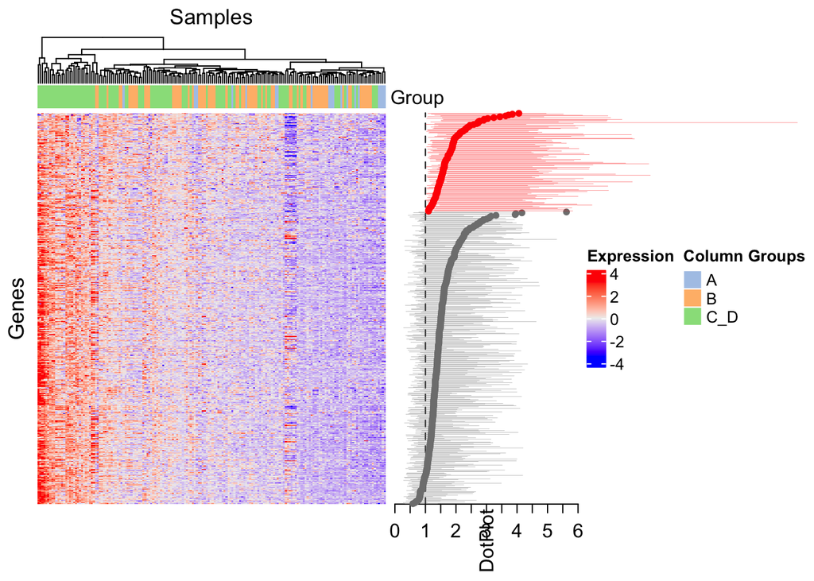

```r
# Custom annotation function for one dot and error bar per row
dot_plot_with_colored_error <- AnnotationFunction(
  fun = function(index) {
    n <- length(index)
    pushViewport(viewport(yscale = c(0.5, n + 0.5), xscale = c(0, 6)))  # Set scales

    # Draw the horizontal axis
    grid.xaxis(at = seq(0, 6, by = 0.5), label = seq(0, 6, by = 0.5))

    # Make the horizontal reference line at x = 1 thinner
    grid.lines(
      x = unit(1, "native"),
      y = unit(c(0.5, n + 0.5), "native"),
      gp = gpar(col = "black", lty = 2, lwd = 1)  # Adjusted line width
    )

    for (i in seq_len(n)) {
      y <- unit(i, "native")  # Set position for the current row
      x <- dot_plot_data$Value[index[i]]  # Value for the current row
      lower <- dot_plot_data$Lower[index[i]]  # Lower bound for the current row
      upper <- dot_plot_data$Upper[index[i]]  # Upper bound for the current row
      pvalue <- dot_plot_data$PValue[index[i]]  # P-value for the current row

      # Determine color based on p-value
      color <- ifelse(pvalue < cox_p_val, "red", "grey50")

      # Plot dot
      grid.points(
        x = unit(x, "native"),
        y = y,
        pch = 16,
        size = unit(2, "mm"),
        gp = gpar(col = color),
        default.units = "native"
      )

      # Make the error bar line thinner
      grid.lines(
        x = unit(c(lower, upper), "native"),
        y = unit(c(i, i), "native"),
        gp = gpar(col = color, lwd = 0.2)  # Adjusted line width
      )
    }
    popViewport()
  },
  which = "row",
  width = unit(4, "cm") # Adjust width for the annotation
)

# Add metadata
df_meta_id <- data.frame(
  SampleID = as.character(df_meta_f$sample_id_psom),
  cohort = df_meta_f$cohort,
  mrn = df_meta_f$mrn,
  HCI_cID = df_meta_f$HCI_cID,
  txt_stat = df_meta_f$txt_stat)

# Example column groups
df_colname <- data.frame(
  SampleID = colnames(heatmap_data)) %>%
  left_join(df_meta_id)
group_colors <- c("A" = "#1f77b4",
                  "B" = "#ff7f0e",
                  "C_D" = "#2ca02c")

group_colors <- c("A" = "#AEC7E8",
                  "B" = "#FFBB78",
                  "C_D" = "#98DF8A")

# Create column annotation
column_anno <- HeatmapAnnotation(
  Group = df_colname$cohort,
  col = list(Group = group_colors),
  annotation_legend_param = list(
    title = "Column Groups",
    at = names(group_colors),
    labels = names(group_colors)
  )
)


# Define the heatmap
ht <- Heatmap(
  heatmap_data,
  name = "Expression",
  row_title = "Genes",
  column_title = "Samples",
  top_annotation = column_anno,
  show_row_names = FALSE,
  show_column_names = FALSE,
  cluster_rows = FALSE
)
# Add the dot plot with colored error bars and p-value-based coloring as a row annotation
dot_plot_anno <- rowAnnotation(
  DotPlot = dot_plot_with_colored_error
)

# Combine heatmap and annotations
draw(ht + dot_plot_anno, heatmap_legend_side = "right", annotation_legend_side = "right")
```

## 8.2 Version 1

Make heatmap better ordered

```r
# Make the heatmap nicer. We want to order sample C_D
sample_CD <- df_colname %>% filter(cohort == "C_D")
mat_tmp <-  heatmap_data[,sample_CD$SampleID]

p_heat <-
  pheatmap::pheatmap(mat_tmp,
           cluster_rows = TRUE,
           cluster_cols = TRUE,
           scale = "none", # Change to none if we scaled the data
           silent = TRUE)
cd_or <- sample_CD$SampleID[p_heat$tree_col$order]


# Just get the mean / median of all genes and order by it
column_medians <- sort(apply(mat_tmp, 2, function(x) median(x, na.rm = TRUE)))


# Re arrange the heamap
# Make cohort A first
o1 <- df_colname %>% filter(cohort == "A") %>% pull(SampleID)
# Cohort B 2nd
o2 <- df_colname %>% filter(cohort == "B") %>% pull(SampleID)

# Now order

mat22_or <- heatmap_data[,c(o1, o2, cd_or)]
mat22_or <- heatmap_data[,c(o1, o2, names(column_medians))]

# New order
new_or <- data.frame(
  SampleID = c(o1, o2, cd_or)
) %>% left_join(df_colname)
# Add the OS data as well (just for cohort C_D)
tmp <- meta_psom_f %>% select(sample_id_psom, death, OS) %>% distinct() %>%
  rename(SampleID = sample_id_psom) %>%
  mutate(SampleID = as.character(SampleID))
new_or <- new_or %>% left_join(tmp)
# Create column annotation
column_anno2 <- HeatmapAnnotation(
  Group = new_or$cohort,
  #OS = new_or$OS,
  col = list(Group = group_colors),
  annotation_legend_param = list(
    title = "Column Groups",
    at = names(group_colors),
    labels = names(group_colors)
  )
)


# Generate a custom color scheme
paletteLength <- 30
mypalette1 <- rev(paletteer::paletteer_c('ggthemes::Red-Blue Diverging', paletteLength))
mypalette1 <- as.character(mypalette1)  # Ensure the colors are character strings

# Define breaks for the colors
myBreaks <- seq(-2, 3, length.out = paletteLength)  # Match the number of breaks to paletteLength

# Create a custom color function using colorRamp2
col_fun <- colorRamp2(myBreaks, mypalette1)


# Define the heatmap
ht <- Heatmap(
  mat22_or,
  name = "Expression",
  row_title = "Genes",
  column_title = "Samples",
  top_annotation = column_anno2,
  show_row_names = FALSE,
  show_column_names = FALSE,
  cluster_rows = FALSE,
  cluster_columns = FALSE,
  column_split = factor((new_or$cohort)),  # Split columns by groups
  gap = unit(2, "mm"),  # Specify gap size between groups
  col = col_fun,  # Apply the custom color function
  heatmap_legend_param = list(
    #title = "Z-score",
    at = seq(-2, 3, by = 1),  # Adjust ticks to match your breaks
    labels = seq(-2, 3, by = 1)  # Labels for each tick
  )
)
# Combine heatmap and annotations
pdf(file.path(wd$outCurr, "Stage_specific_heatmap.pdf"), height = 6, width = 12)
draw(ht + dot_plot_anno, heatmap_legend_side = "right", annotation_legend_side = "right")
dev.off()
```

# 9 Save objects

```r
save(
  res_dis_mult, uni_sig,
  file = file.path(wd$outData, "04_data.Rdata"))
```